# Metabolism explainer

Jeffrey A. Walker

8/6/2020

# Catabolism and ATP synthesis

**Catabolism** is the subset of metabolism that includes the breakdown of big molecules to small molecules. But typically when a physiologist is talking about catabolic pathways, they are referring to the pathways for ATP synthesis. Another term used alot is **oxidiation**, for example “the oxidation of glucose” or the “oxidation of fatty acids”. Oxidation reactions are one half of coupled **oxidation-reduction (redox)** reactions. In these reactions, energy is transferred from one substrate to the other, ultimately in the form of an electron (e-). The substrate that gives up the e- is **oxidized**. The substrate that receives the electron is **reduced**. So when we say “the oxidation of glucose” we mean the set of reactions that remove energy from glucose and pass it along but this is always in the context of ultimately using this energy to synthesize ATP.

The major fuels for ATP synthesis are glucose, fatty acids (FA), and to a lesser extent, amino acids (also alcohol if you drink alot). Let’s focus on oxidation of glucose and FA.

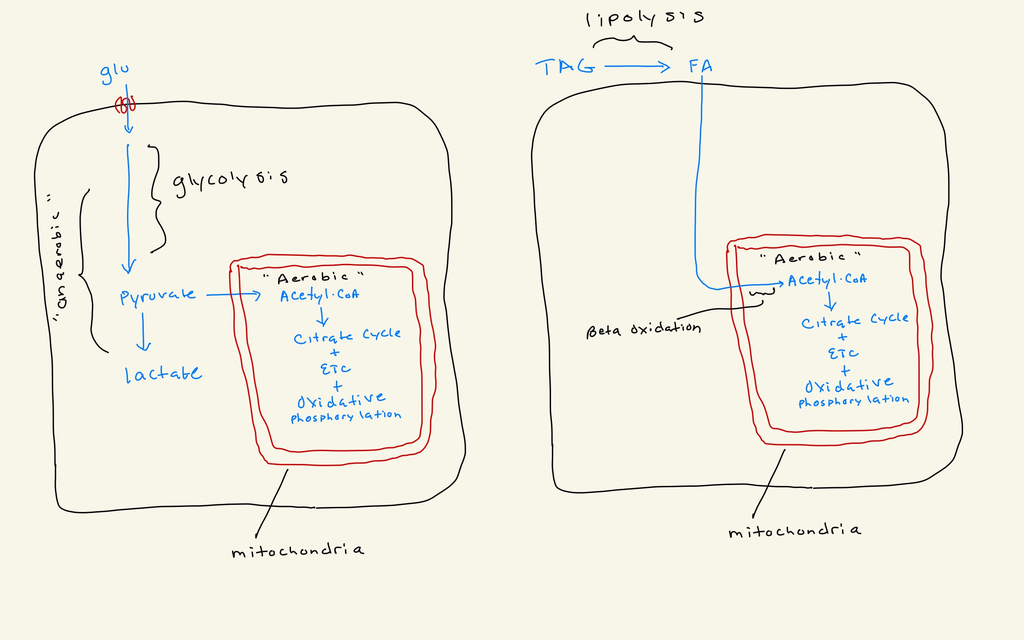

The big picture for glucose is that it is 1) oxidized to pyruvate in the cytosol in a process called **glycolysis**. This generates a little bit of ATP. There is still a bunch of energy left in pyruvate and one fate of pyruvate is to diffuse into the mitochondria and be fully oxidized to CO2 and H2O. The first step of this is the oxidation of pyruvate to **acetyl-coA**. Acetyl-coA is a super important “hub” molecule with many fates but one fate is that it is an inital substrate for **aerobic pathway** for ATP synthesis which includes different “parts”: **citrate cycle**, **electron transport**, and **oxidative phosphorylation**. The arobic pathway generates a lot of ATP.

The big picture for FA is that these are transported into the mitochondria and are oxided to acetyl-CoA in a process called **beta-oxidation**. **Acetyl-CoA** then enters the aerobic pathway for ATP synthesis.

**Conception/Misconception** – Many students have the wrong working definition of **anaerobic** and most textbooks (even very good textbooks) actively encourage this misconception. Glycolysis generates a small amount of ATP and is an **anaerobic** pathway because O2 is not a substrate in any of the reactions. Many students and even instructors think anaerobic means the cell has no O2. Cells always have abundant O2 (unless you are George Clooney at the end of the movie Gravity - where he floats off into space). The pathway for ATP synthesis in the mitochondria is called **aerobic** because O2 is a substrate. The aerobic pathway is also called **respiration** or **cellular respiration**.

A concept that is here to stay but is a terrible name is **anaerobic respiration** for the path glucose -> lactate, a name that is used in exercise physiology and cancer biology (I would call the glucose -> lactate path **anaerobic path for ATP synthesis** but an even better name is **fermentation**). The reason anaerobic respiration is a terrible name is because “respiration” implies an electron transport chain that generates an ion gradient to synthsize ATP and some kind of “final electron acceptor” such as (but not necessarily) O2. So glucose -> lactate is not “respiration”. True anaerobic respiration exists in some bacteria but this isn’t the path glucose -> lactate.